# Análisis de COMPAS como predictor sesgado

**Ignacia Aguilera, Camilo Ramírez** - *Grupo 16*  
Curso CC5206 Introducción a la Minería de Datos  
Profesores: Felipe Bravo, Bárbara Poblete  
Facultad de Ciencias Físicas y Matemáticas, Universidad de Chile

# Introducción y motivación

Este informe se enmarca en el curso de Introducción a la Minería de Datos (CC5206) de la Universidad de Chile, para documentar el hito inicial (1) del proyecto minería de datos sobre el dataset asociado a COMPAS de [Northpointe](https://www.northpointe.com/) generado por [ProPublica](https://www.propublica.org/).

COMPAS es el acrónimo de *Correctional Offender Management Profiling for Alternative Sanctions*, que es traducible como “Gestión de perfiles de reos penitenciarios para penas alternativas” y corresponde a un algoritmo que busca predecir la probabilidad de reincidencia de un criminal al asignarle un puntaje (*score*) que representa la misma ([se puede encontrar su documentación aquí](https://assets.documentcloud.org/documents/2840784/Practitioner-s-Guide-to-COMPAS-Core.pdf)). Este método pertenece a la familia de algoritmos de evaluación de riesgo penitenciario (*risk assesment*) y se ha utilizado en diversas cortes de Estados Unidos como insumo para los jueces en la determinación del otorgamiento de libertad condicional a los imputados por algún delito.Esto responde a la necesidad de ese país de doscongestionar sus prisiones de forma eficiente. Es importante distinguir que este algoritmo no fue diseñado ni se ha utilizado para determinar la culpabilidad de alguna persona en un delito, ni para determinar una pena.

Un [estudio](https://www.propublica.org/article/machine-bias-risk-assessments-in-criminal-sentencing) realizado por ProPublica encontró un significativo sesgo racial en los resultados de puntaje COMPAS a desfavor de las personas afroamericanas a pesar que este atributo de las personas no se ingresaba como entrada al algoritmo. ProPublica además de publicar los resultados del estudio, publicó su [metdología](https://github.com/caitlinkuhlman/bpdmtutorial/blob/master/tutorial-COMPAS.ipynb) y un dataset generado a partir de la reccopilación de datos realizada por la agencia periodística. Las publicaciones se encuentran presente en el [repositorio de GitHub](https://github.com/propublica/compas-analysis) de ProPublica

# Problemática central

La problematica a abordar en este proyecto se basa en el análisis de datos del dataset “compas”, principalmente al estudio efectuado por ProPublica que revela una serie de sesgos que son identificables en la metodologia de estimación para predecir la probabilidad de reincidencia de un criminal debido a estos datos es necesario un análisis para poder identificar datos relevantes.

El objetivo de este proyecto es analizar y detectar los posibles sesgos que tenga COMPAS en un espectro más amplio de atributos además de verificar el sesgo racial descrito por el informe de ProPublica. Adicional a esto se busca determinar una forma de disminuir los sesgos detectados o determinar la imposibilidad de realizar lo anterior mediante la exploración de los datos correspondientes en el hito 1.

Para esto se pretende abordar en tornos a los datos, las correlaciones entres los distintos atributos como indice de reinicidencia, raza, sexo, rango de edad, etc. Esto permitira encontrar sesgos que podran ser los mismo presentados por ProPublica y/o otros. Para cumplir este objetivo se trabaja con el dataset principal publicado en el repositorio contenido en el fichero `compas.db` que corresponde a una base de datos de sqlite3. Esta se importa en R y utilizando esta herramienta, se hace un análisis de datos, eventualmente una limpieza y reducción de atributos para comenzar a analizar correlaciones que se puedan encontrar, los atributos que se consideran de interés corresponden a la etnia (raza) y género de las personas. En base a correlaciones de interés encontradas, se aplicarán herramientas de minería de datos más sofisticadas en los próximos hitos del proyecto.

Otras formas de encontrar relaciones y explorar los datos para el hito 1, sera relacionar las salidas del sistema con las variables de entrada, tambien podemos definir relaiones de interdependencia entre las variables que componen el dataset.

# Descripción de los datos

En primer lugar, para trabajar de manera cómoda con la base de datos, es necesario contar con un diagrama Entidad-Relación de esta. Así es posible realizar una inspección visual de las tablas de manera compacta y hacerse una idea del entorno sobre el cuál se trabaja. Para crear este diagrama, se hizo uso de un software llamado [DB Browser for SQLite](https://sqlitebrowser.org/) que permite convertir ficheros de extensión *.db* a ficheros con instrucciones SQL para recrear esta base de datos en cualquier sistema que permita dicho lenguaje. Dentro de este programa, se abrió el archivo `compas.db` para luego exportarlo en formato SQL.

Obtenido un archivo `compas.sql`, se hace uso de un segundo software: [MySQL Workbench](https://www.mysql.com/products/workbench/). Este permite leer archivos de extensión *.sql* para generar una nueva base de datos. Para continuar el proceso, dentro del programa se debe crear un nuevo modelo para posteriormente importar el nuevo archivo generado anteriormente. Al hacerlo, se genera automáticamente un diagrama de Entidad-Relación, este se muestra a continuación:

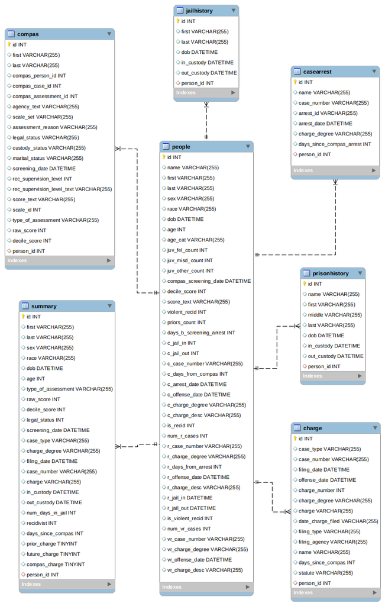

Diagrama de Entidad-Relación generado por MySQL Wekbench

Es necesario mencionar que las instrucciones SQL del archivo generado con la herramienta *DB Browser* no cuentan con un máximo de caracteres para las columnas de tipo *VARCHAR* por lo que se debe editar manualmente para añadir un máximo de caracteres como sigue: *VARCHAR(255)*. A partir de este diagrama, es posible identificar que la tabla **people** (relativa a las personas) es la columna vertebral de esta base de datos. Alrededor de esta tabla, se pueden encontrar seis más (“compas”, “jailhistory”, “casearrest,”summary“,”prisonhistory" y “charge”) con distintos atributos que pertenecen a una persona en específico (notar la llave foránea al id de una persona), estos datos serán analizados posteriormente.

# Exploración de datos

A modo de hacer el informe replicable, se deja explícito el código fuente utilizado. Para trabajar con `compas.db` se comienza importando las librerías requeridas, importando el fichero de la base de datos a través de una clase de SQL manejable por R para posteriormente extraer los dataframes del mismo.

```r
library(RSQLite)

filename <- "compas.db"
sqlite.driver <- dbDriver("SQLite")
db <- dbConnect(sqlite.driver, dbname = filename)

people        <- dbReadTable(db,"people")
```

```r
casearrest    <- dbReadTable(db,"casearrest")
charge        <- dbReadTable(db,"charge")
compas        <- dbReadTable(db,"compas")
jailhistory   <- dbReadTable(db,"jailhistory")
prisonhistory <- dbReadTable(db,"prisonhistory")
summary       <- dbReadTable(db,"summary")
```

Es posible además mostrar el tamaño de cada Dataframe:

```r
dim1 <- paste(" casearrest rows:", dim(casearrest)[1],"; cols:", dim(casearrest)[2],"\n")
dim2 <- paste("charge rows:", dim(charge)[1],"; cols:", dim(charge)[2],"\n")
dim3 <- paste("compas rows:", dim(compas)[1],"; cols:", dim(compas)[2],"\n")
dim4 <- paste("jailhistory rows:", dim(jailhistory)[1],"; cols:", dim(jailhistory)[2],"\n")
dim5 <- paste("prisonhistory rows:", dim(prisonhistory)[1],"; cols:", dim(prisonhistory)[2],"\n")
dim6 <- paste("summary rows:", dim(summary)[1],"; cols:", dim(summary)[2],"\n")
dim7 <- paste("people rows:", dim(people)[1],"; cols:", dim(people)[2],"\n")
cat(paste(dim1,dim2,dim3,dim4,dim5,dim6,dim7))
```

```
 casearrest rows: 128183 ; cols: 8
 charge rows: 148086 ; cols: 15
 compas rows: 37578 ; cols: 21
 jailhistory rows: 22111 ; cols: 7
 prisonhistory rows: 4945 ; cols: 9
 summary rows: 0 ; cols: 26
 people rows: 11757 ; cols: 41
```

Dado que la relación *summary* no tiene ninguna tupla, se descarta trbajar con ella, por otro lado, se sabe que la relación central del database corresponde a *people*, por lo que conviene enlistar y obtener un extracto de sus atributos.

```r
str(people)
```

```
'data.frame':   11757 obs. of  41 variables:
 $ id                     : int  1 2 3 4 5 6 7 8 9 10 ...
 $ name                   : chr  "miguel hernandez" "michael ryan" "kevon dixon" "ed philo" ...
 $ first                  : chr  "miguel" "michael" "kevon" "ed" ...
 $ last                   : chr  "hernandez" "ryan" "dixon" "philo" ...
 $ sex                    : chr  "Male" "Male" "Male" "Male" ...
 $ race                   : chr  "Other" "Caucasian" "African-American" "African-American" ...
 $ dob                    : chr  "1947-04-18 00:00:00.000000" "1985-02-06 00:00:00.000000" "1982-01-22 00:00:00.000000" "1991-05-14 00:00:00.000000" ...
 $ age                    : int  69 31 34 24 23 43 44 41 43 39 ...
 $ age_cat                : chr  "Greater than 45" "25 - 45" "25 - 45" "Less than 25" ...
 $ juv_fel_count          : int  0 0 0 0 0 0 0 0 0 0 ...
 $ juv_misd_count         : int  0 0 0 0 1 0 0 0 0 0 ...
 $ juv_other_count        : int  0 0 0 1 0 0 0 0 0 0 ...
 $ compas_screening_date  : chr  "2013-08-14 00:00:00.000000" "2014-12-31 00:00:00.000000" "2013-01-27 00:00:00.000000" "2013-04-14 00:00:00.000000" ...
 $ decile_score           : int  1 5 3 4 8 1 1 6 4 1 ...
```

[output cut: 27 more lines]

En base a lo observado se pueden analizar los atributos y eventualmente reducir la dimensionalidad de los datos.

- `id` es la llave primaria de la relación, permite identificar a una única persona
- `name`, `first` y `last` tienen relación con el nombre de las personas, dado que estas ya son identificables por `id`, estas relaciones son prescindibles.
- `sex` y `race` corresponden al sexo y raza de las personas y son atributos demográficos categóricos de interés y donde se centró el análisis realizado por ProPublica.
- `dob` *(date of birth)*, `age` y `age_cat` son atributos que tienen relacion con la edad de las personas, en particular `dob` aporta su fecha de nacimiento, con lo que se pueden inferir los otros dos, aún así, para el análisis que se desea realizar basta conservar el atributo `age`.
- `juv_fel_count` *(juvenile fellonies count)*, `juv_misd_count` *(juvenile misdemeanor count)*, `juv_other_count` corresponden a atributos que cuentan la cantidad de delitos graves *(fellonies)*, menores *(misdemeanor)* u otros que cometió una persona durante su juventud.
- `compas_screening_date` corresponde a la fecha en la que se calculó el puntaje de esta persona con COMPAS, a efectos del análisis de sesgos, se considera irrelevante.
- `decile_score` corresponde a la asignación numérica del puntaje, mientras en el dataset `score_text` solo arroja valores NA (verificable con `people[!is.na(people$score_text), ]`). El resto de los atributos corresponden a detalles respecto a su reclusión tanto en su caso original como en aquel que reincidieron posterior a su liberación condicional, respecto a esto hay un atributo de importancia, que corresponde a:
- `is_recid`, indica si existe reincidencia en la persona analizada por COMPAS, adquiere valor `-1` en caso de no haber.

Para comprender la demografía involucrada, a continuación se enlistan los atributos de sexo y raza y se asignan como factores categoricos junto al puntaje.

```r
people$sex <- as.factor(people$sex)
people$race <- as.factor(people$race)
people$decile_score <- as.factor(people$decile_score)

summary(people$sex)
```

```
Female   Male
  2421   9336
```

```r
summary(people$race)
```

```
African-American            Asian        Caucasian         Hispanic
            5813               58             4085             1100
 Native American            Other
              40              661
```

```r
summary(people$decile_score)
```

```
  -1    1    2    3    4    5    6    7    8    9   10
  15 2577 1572 1259 1199 1034  993  900  796  802  610
```

Considerando estas categorías, se hace un breve análisis etáreo de los puntajes:

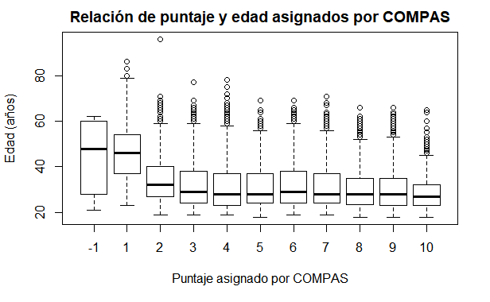

```r
plot(people$decile_score, people$age,
     xlab="Puntaje asignado por COMPAS",ylab="Edad (años)",
     main="Relación de puntaje y edad asignados por COMPAS")
```

Lo que muestra una leve correlación donde a medida que aumenta el puntaje COMPAS disminuye la edad, esto se puede corroborar con la función de correlación:

```r
cor(people$age, as.numeric(people$decile_score))
```

```
[1] -0.37658
```

Tambien es posible observar la distribución de edades del dataset, esto con un gráfico de densidad.

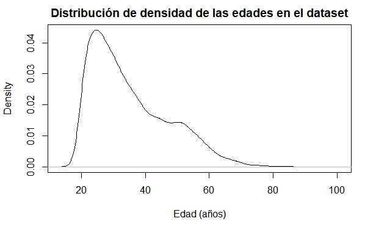

```r
plot(density(people$age),xlab="Edad (años)",
     main="Distribución de densidad de las edades en el dataset")
```

Evidentemente existe una concentración de población joven en el dataset. Por otro lado, se hace un análisis por sexo de los puntajes.

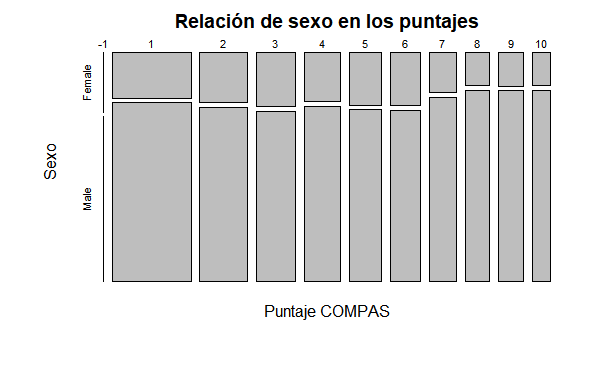

```r
plot(table(people$decile_score,people$sex),
     xlab="Puntaje COMPAS",ylab="Sexo",
     main="Relación de sexo en los puntajes")
```

Finalmente focalizado a lo estudiado por ProPublica, se genera una tabla de contingencia en relación a los puntajes COMPAS y la raza.

```r
table(people$race,people$decile_score)
```

```
                     -1    1    2    3    4    5    6    7    8    9   10
  African-American    6  694  623  573  589  525  585  595  566  587  470
  Asian               0   27    9    8    0    5    4    1    3    0    1
  Caucasian           8 1192  610  480  450  380  301  228  179  166   91
  Hispanic            0  376  203  135   84   85   64   50   34   37   32
  Native American     0    4    7    6    6    1    4    5    1    2    4
  Other               1  284  120   57   70   38   35   21   13   10   12
```

Notar que la muestra de asiaticos y nativos americanos es mínima, por ende se deciden descartar de al obserbación de puntajes a nivel racial, asimismo aquellas personas en la categoría *others* ya que no se aporta información clarificadora. Considerado esto se hace un gráfico.

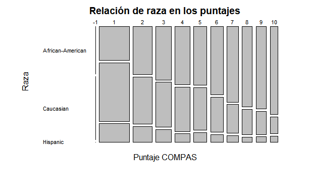

```r
reducedPeople <- people[people$race=="African-American"|people$race=="Caucasian"|people$race=="Hispanic",]
reducedPeople$race <- factor(reducedPeople$race)

plot(table(reducedPeople$decile_score, reducedPeople$race),
     xlab="Puntaje COMPAS",ylab="Raza",
     main="Relación de raza en los puntajes",las=1)
```

Finalmente, y a modo resumen, se incluye una gráfica que cuantifica la totalidad de personas a las que se le asignó determinado puntaje según e algoritmo de COMPAS.

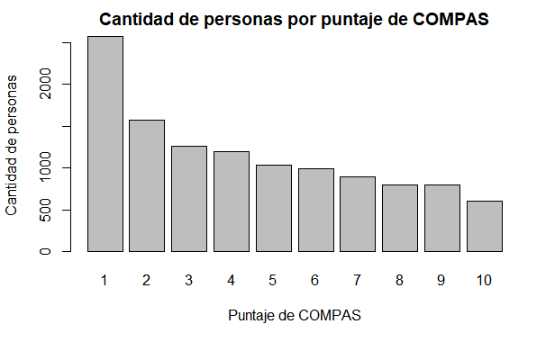

```r
barplot(table(as.numeric(factor(people$decile_score,exclude=-1))),
        xlab="Puntaje de COMPAS",ylab="Cantidad de personas",
        main="Cantidad de personas por puntaje de COMPAS")
```

# Conclusión

Respecto a la exploración de datos realizada en este hito, se puede ver una correlación de puntajes con la edad y la raza de las personas. Como eventual trabajo propuesto para el segundo hito del proyecto, queda establecer una métrica del sesgo en el dataset observando según los datos de reincidencia los falsos negativos y falsos positivos, por otro lado hacer un clasificador que sea capaz de predecir los campos de entrada a partir de la salida y finalmente predecir variables ocultas.

Respecto al objetivo de este hito, este se considera en general cumplido, ya que se logó obtener información suficiente para focalizar la búsqueda de sesgos en un análisis de mayor profundidad, además que se verificaron los resultados del estudio realizado por ProPublica

El desarrollo de hito 1 presentó inconvenientes, en particular la salida de dos alumnos del proyecto lo que dificultó la distribución del trabajo y la carga que cada integrante tuvo que abordar.

*La distribución de trabajo por integrante fue la siguiente:*  
**Ignacia Aguilera**: Redactó la problemática central y la conclusión, además de la generación de grádicas en la exploración de datos, en particular graficas de resumen de datos.  
**Camilo Ramírez**: Redactó la introducción y motivación, realizó la importación, limpieza y descripción de los datos, así como la descripción de atributos y la generación de tablas de contingencia y gráficas de correlación, en particular de puntaje-sexo y puntaje-raza.

**Sebastán Zapata** *(abandonó el proyecto durante su transcurso)*: Se encargó de realizar el análisis de Entidad-Relación del database, generando el diagrama E-R presente en el mismo.